# rsynthea: Generación de pacientes sintéticos para investigación

## ¿Qué es rsynthea?

**rsynthea** es un generador de historiales clínicos sintéticos para R. Simula cohortes de pacientes virtuales usando los 243 módulos de enfermedad del [Generic Module Framework (GMF) de Synthea](https://github.com/synthetichealth/synthea), produciendo datos que imitan la epidemiología de la población de Massachusetts (EEUU).

**Casos de uso principales:**

- Prototipar pipelines de datos clínicos sin datos reales
- Enseñanza y formación en salud computacional
- Benchmarking de algoritmos de IA clínica
- Estudios de simulación epidemiológica

**Rendimiento** (Linux x86, 20 pacientes):

| Motor | Tiempo | vs Java Synthea |
| --- | --- | --- |
| rsynthea C++ (serial) | ~5s | 2.7× más rápido |
| rsynthea C++ (6 cores) | ~1.5s | 9× más rápido |
| Java Synthea | 13.4s | — |

## Instalación

```r
# Desde GitHub
devtools::install_github("joscani/rsynthea")
```

## Uso básico

### 1. Generar una cohorte

Los módulos GMF se cargan y compilan automáticamente en la primera llamada y quedan en caché para el resto de la sesión:

```r
library(rsynthea)

tbls <- generate_population(
  n        = 200,
  seed     = 42L,
  end_date = as.POSIXct("2023-01-01"),
  min_age  = 40L,
  max_age  = 65L
)

names(tbls)
```

```
#> [1] "patients"      "encounters"    "conditions"    "medications"
#> [4] "procedures"    "observations"  "allergies"     "immunizations"
```

### 2. Explorar los datos generados

```r
# Demografía
dplyr::glimpse(tbls$patients)

# Condiciones más frecuentes
tbls$conditions |>
  dplyr::count(code, description, sort = TRUE) |>
  dplyr::slice_head(n = 10)

# Encuentros por paciente
tbls$encounters |>
  dplyr::count(patient_id, name = "n_visitas") |>
  summary()
```

## Ejemplo práctico: análisis de diabetes tipo 2

```r
library(rsynthea)
library(dplyr)
library(ggplot2)
```

```r
tbls <- generate_population(
  n        = 200,
  seed     = 1L,
  end_date = as.POSIXct("2023-01-01"),
  min_age  = 30L,
  max_age  = 75L
)
```

[output not shown]

```r
cat(sprintf("Pacientes: %d  |  Encuentros: %d  |  Condiciones: %d  |  Medicaciones: %d\n",
    nrow(tbls$patients), nrow(tbls$encounters),
    nrow(tbls$conditions), nrow(tbls$medications)))
```

```
#> Pacientes: 200  |  Encuentros: 63238  |  Condiciones: 9143  |  Medicaciones: 1874
```

### Prevalencia de condiciones crónicas

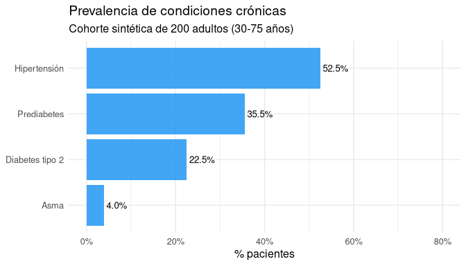

```r
prevalencia <- tbls$conditions |>
  filter(code %in% c("44054006", "714628002", "59621000", "195967001")) |>
  group_by(code, description) |>
  summarise(n_pacientes = n_distinct(patient_id), .groups = "drop") |>
  mutate(
    prevalencia = n_pacientes / nrow(tbls$patients) * 100,
    descripcion = case_when(
      code == "44054006" ~ "Diabetes tipo 2",
      code == "714628002" ~ "Prediabetes",
      code == "59621000" ~ "Hipertensión",
      code == "195967001" ~ "Asma",
      TRUE ~ description
    )
  )

ggplot(prevalencia, aes(x = reorder(descripcion, prevalencia), y = prevalencia)) +
  geom_col(fill = "#2196F3", alpha = 0.85) +
  geom_text(aes(label = sprintf("%.1f%%", prevalencia)), hjust = -0.1, size = 3.5) +
  coord_flip() +
  scale_y_continuous(limits = c(0, 80), labels = function(x) paste0(x, "%")) +
  labs(
    title    = "Prevalencia de condiciones crónicas",
    subtitle = "Cohorte sintética de 200 adultos (30-75 años)",
    x = NULL, y = "% pacientes"
  ) +
  theme_minimal(base_size = 12)
```

### Comorbilidades del paciente diabético

```r
dm_ids     <- tbls$conditions |> filter(code == "44054006") |> pull(patient_id) |> unique()
non_dm_ids <- tbls$patients$id[!tbls$patients$id %in% dm_ids]

cat(sprintf("Pacientes con diabetes tipo 2: %d / %d (%.1f%%)\n",
    length(dm_ids), nrow(tbls$patients),
    100 * length(dm_ids) / nrow(tbls$patients)))
```

```
#> Pacientes con diabetes tipo 2: 45 / 200 (22.5%)
```

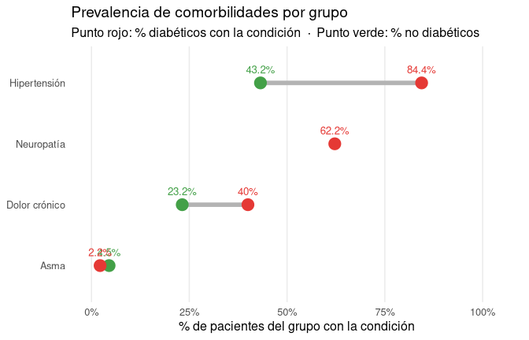

```r
comorb_codes <- c(
  "59621000"        = "Hipertensión",
  "82423001"        = "Dolor crónico",
  "368581000119106" = "Neuropatía",
  "195967001"       = "Asma"
)

comorb <- tbls$conditions |>
  filter(code %in% names(comorb_codes)) |>
  distinct(patient_id, code) |>
  mutate(
    es_diabetico = patient_id %in% dm_ids,
    condicion    = comorb_codes[code]
  ) |>
  group_by(condicion, es_diabetico) |>
  summarise(n = n(), .groups = "drop") |>
  mutate(
    total = ifelse(es_diabetico, length(dm_ids), length(non_dm_ids)),
    pct   = round(n / total * 100, 1),
    grupo = ifelse(es_diabetico, "Diabético", "No diabético")
  )

# Pivot wide para dumbbell (sin tidyr)
dm_pct   <- comorb |> filter(grupo == "Diabético")    |> select(condicion, Diabético      = pct)
nodm_pct <- comorb |> filter(grupo == "No diabético") |> select(condicion, `No diabético` = pct)
comorb_wide <- merge(dm_pct, nodm_pct, by = "condicion", all = TRUE) |>
  mutate(condicion = reorder(condicion, Diabético))

ggplot(comorb_wide) +
  geom_segment(
    aes(y = condicion, yend = condicion,
        x = `No diabético`, xend = Diabético),
    color = "grey70", linewidth = 2, na.rm = TRUE
  ) +
  geom_point(aes(y = condicion, x = `No diabético`),
             color = "#43A047", size = 5, na.rm = TRUE) +
  geom_point(aes(y = condicion, x = Diabético),
             color = "#E53935", size = 5) +
  geom_text(aes(y = condicion, x = `No diabético`,
                label = paste0(`No diabético`, "%")),
            color = "#43A047", vjust = -1.2, size = 3.5, na.rm = TRUE) +
  geom_text(aes(y = condicion, x = Diabético,
                label = paste0(Diabético, "%")),
            color = "#E53935", vjust = -1.2, size = 3.5) +
  scale_x_continuous(labels = function(x) paste0(x, "%"), limits = c(0, 105)) +
  labs(
    title    = "Prevalencia de comorbilidades por grupo",
    subtitle = "Punto rojo: % diabéticos con la condición  ·  Punto verde: % no diabéticos",
    x = "% de pacientes del grupo con la condición", y = NULL
  ) +
  theme_minimal(base_size = 12) +
  theme(panel.grid.major.y = element_blank(),
        panel.grid.minor   = element_blank())
```

### Distribución por edad y género

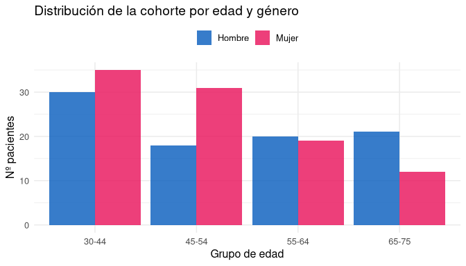

```r
tbls$patients |>
  mutate(
    edad = as.numeric(as.POSIXct("2023-01-01") - birth_date, units = "days") / 365.25,
    grupo_edad = cut(edad, breaks = c(30, 45, 55, 65, 75),
                     labels = c("30-44", "45-54", "55-64", "65-75"))
  ) |>
  filter(!is.na(grupo_edad)) |>
  count(grupo_edad, gender) |>
  mutate(gender = ifelse(gender == "F", "Mujer", "Hombre")) |>
  ggplot(aes(x = grupo_edad, y = n, fill = gender)) +
  geom_col(position = "dodge", alpha = 0.85) +
  scale_fill_manual(values = c("Mujer" = "#E91E63", "Hombre" = "#1565C0")) +
  labs(
    title = "Distribución de la cohorte por edad y género",
    x = "Grupo de edad", y = "Nº pacientes", fill = NULL
  ) +
  theme_minimal(base_size = 12) +
  theme(legend.position = "top")
```

## Ejemplo avanzado: seguimiento longitudinal

rsynthea genera historiales completos desde el nacimiento. Esto permite análisis longitudinales reales, como la evolución de la HbA1c en pacientes diabéticos a lo largo del tiempo (código LOINC 4548-4).

```r
ha1c <- tbls$observations |>
  filter(code == "4548-4") |>
  inner_join(
    tbls$conditions |> filter(code == "44054006") |> distinct(patient_id),
    by = "patient_id"
  ) |>
  mutate(
    anyo       = as.integer(format(time, "%Y")),
    ha1c_valor = as.numeric(value)
  ) |>
  filter(!is.na(ha1c_valor), ha1c_valor > 4, ha1c_valor < 15) |>
  group_by(anyo) |>
  summarise(
    media = mean(ha1c_valor),
    p25   = quantile(ha1c_valor, 0.25),
    p75   = quantile(ha1c_valor, 0.75),
    n     = n(),
    .groups = "drop"
  )

cat(sprintf("Observaciones HbA1c en diabéticos: %d  |  Años: %d–%d\n",
    sum(ha1c$n), min(ha1c$anyo), max(ha1c$anyo)))
```

```
#> Observaciones HbA1c en diabéticos: 1371  |  Años: 1966–2022
```

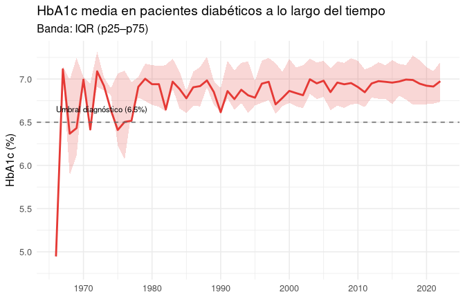

```r
ggplot(ha1c, aes(x = anyo)) +
  geom_ribbon(aes(ymin = p25, ymax = p75), alpha = 0.2, fill = "#E53935") +
  geom_line(aes(y = media), color = "#E53935", linewidth = 1) +
  geom_hline(yintercept = 6.5, linetype = "dashed", color = "grey40") +
  annotate("text", x = min(ha1c$anyo), y = 6.65,
           label = "Umbral diagnóstico (6.5%)", hjust = 0, size = 3) +
  scale_x_continuous(breaks = scales::breaks_pretty(n = 8)) +
  labs(
    title    = "HbA1c media en pacientes diabéticos a lo largo del tiempo",
    subtitle = "Banda: IQR (p25–p75)",
    x = NULL, y = "HbA1c (%)"
  ) +
  theme_minimal(base_size = 12)
```

## Notas sobre los datos generados

Los datos producidos por rsynthea son **sintéticos** y no corresponden a personas reales. Sin embargo, los módulos GMF están calibrados para reproducir:

- Prevalencias de enfermedades crónicas de Massachusetts (EEUU)
- Distribuciones de edad, género y etnia
- Progresión natural de enfermedades (diabetes, hipertensión, EPOC…)
- Patrones de encuentros médicos y prescripción

Para generar poblaciones representativas de otras regiones, considerar ajustar las probabilidades de los módulos base.

## Referencias

- [Synthea™ Patient Generator](https://synthetichealth.github.io/synthea/)
- [Generic Module Framework (GMF)](https://github.com/synthetichealth/synthea/wiki/Generic-Module-Framework)
- Walonoski J, et al. (2018). *Synthea: An approach, method, and software mechanism for generating synthetic patients and the synthetic electronic health care record.* JAMIA.